# January 2019 Flight Delay: Data-Quality and Priority-Date Review

Reway Du

2026-08-28

# Purpose

This report is a portfolio reanalysis of a January 2019 U.S. flight extract. It asks two deliberately limited questions:

1. Is the supplied file internally consistent enough for delay analysis?
2. Which dates deserve further operational review based on several transparent delay-severity measures?

The analysis produces an investigation queue, not a causal claim about an airline, airport, weather event, or operational failure.

# Data audit

The supplied extract contains 583,985 records and 17 usable fields. It does not include carrier, flight number, cancellation/diversion, scheduled time, weather, or delay-cause fields. Missing arrival outcomes are retained and reported rather than silently treated as on-time flights.

Internal data-quality checks

| check | value |
| --- | --- |
| Source records | 583985 |
| Usable source fields | 17 |
| All records from January 2019 | 583985 |
| Day-of-week mismatches | 0 |
| Invalid known arrival-time HHMM values | 0 |
| Arrival-delay-new contradictions | 0 |
| Late-15 flag contradictions | 0 |
| Indistinguishable duplicate rows | 7145 |
| Missing departure delay | 16355 |
| Missing arrival delay | 18022 |

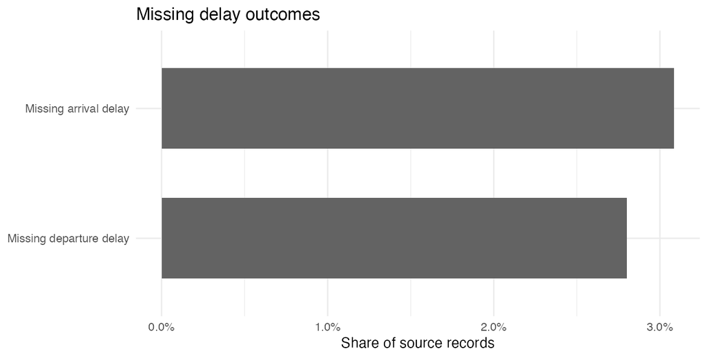

The 18,022 records without an arrival-delay outcome may include materially disrupted flights. Consequently, all severity rates are conditional on known arrival outcomes and may understate disruption.

# Daily disruption profile

For each date, the review calculates flight volume, missing-outcome rate, mean and median arrival delay, the 95th percentile, the share at least 15 minutes late, the share at least 60 minutes late, and the share that worsened by at least 60 minutes after departure.

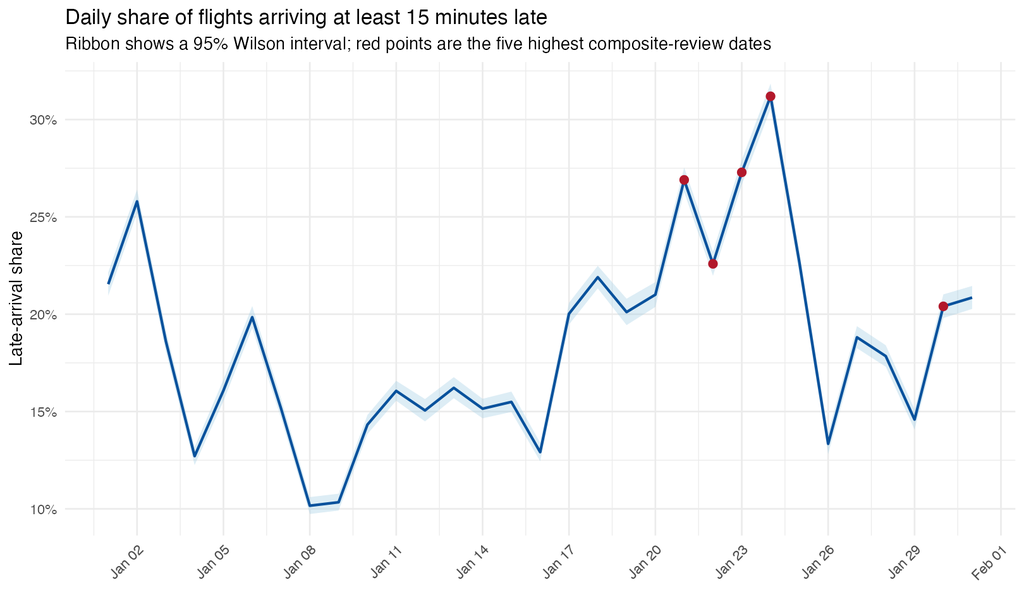

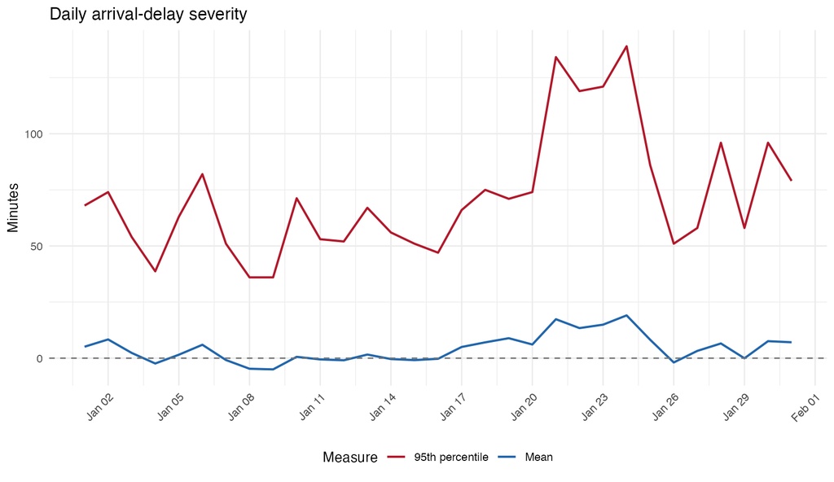

# Priority dates

The priority score is the average percentile rank across five measures: mean delay, 95th-percentile delay, late-15 rate, severe-60 rate, and post-departure worsening rate. It is a relative review score within January 2019, not a probability or calibrated anomaly confidence.

The highest-scoring date is **January 24, 2019**. Among flights with known arrival outcomes, 31.2% arrived at least 15 minutes late; mean arrival delay was 19.1 minutes and the 95th percentile was 139 minutes.

Highest-priority dates for follow-up review

| Date | Flights | Known arrivals | Missing arrival outcome | Mean delay (min) | P95 delay (min) | Late 15+ | Priority score |
| --- | --- | --- | --- | --- | --- | --- | --- |
| 2019-01-24 | 19963 | 19503 | 2.3% | 19.1 | 139.0 | 31.2% | 98.7 |
| 2019-01-23 | 19099 | 18458 | 3.4% | 14.9 | 121.0 | 27.3% | 94.2 |
| 2019-01-21 | 19511 | 18858 | 3.3% | 17.4 | 134.1 | 26.9% | 92.3 |
| 2019-01-22 | 18657 | 17395 | 6.8% | 13.4 | 119.0 | 22.6% | 86.5 |
| 2019-01-30 | 19102 | 16914 | 11.5% | 7.6 | 96.0 | 20.4% | 82.9 |
| 2019-01-25 | 20041 | 19826 | 1.1% | 8.2 | 86.0 | 22.7% | 81.3 |
| 2019-01-18 | 20009 | 19534 | 2.4% | 7.0 | 75.0 | 21.9% | 74.8 |
| 2019-01-28 | 19934 | 18435 | 7.5% | 6.5 | 96.0 | 17.8% | 73.9 |
| 2019-01-31 | 19962 | 18160 | 9.0% | 7.1 | 79.0 | 20.9% | 69.7 |
| 2019-01-19 | 14935 | 13382 | 10.4% | 8.9 | 71.0 | 20.1% | 67.7 |

# Sensitivity check

To check whether one measure alone drives the ranking, the score is recalculated five times, each time leaving out one component. The table reports how many of the original top five dates remain.

Leave-one-metric-out priority-score sensitivity

| excluded_metric | overlap_with_full_top5 | top5_dates |
| --- | --- | --- |
| mean_arrival_delay | 5 | 2019-01-21, 2019-01-22, 2019-01-23, 2019-01-24, 2019-01-30 |
| p95_arrival_delay | 5 | 2019-01-21, 2019-01-22, 2019-01-23, 2019-01-24, 2019-01-30 |
| late15_rate | 5 | 2019-01-21, 2019-01-22, 2019-01-23, 2019-01-24, 2019-01-30 |
| severe60_rate | 5 | 2019-01-21, 2019-01-22, 2019-01-23, 2019-01-24, 2019-01-30 |
| worsening60_rate | 4 | 2019-01-21, 2019-01-22, 2019-01-23, 2019-01-24, 2019-01-25 |

# Limitations

- Known-arrival statistics can be biased if missing outcomes represent the most disrupted flights.
- The file lacks carrier, schedule, cancellation/diversion, weather, and causal delay fields.
- Daily observations are not independent flight-level experiments.
- The composite score is a triage device and should be paired with source-record review and external operational context.
- A later month or external event labels would be required for genuine out-of-sample validation.

# Portfolio context

This independent, shortened portfolio edition was inspired by a collaborative STA 4320 course project. It focuses on data validation and priority-date review. It does not present the original team submission or claim sole authorship of work completed by other team members. The archived contribution statement attributes Tasks 1 and 2, overall formatting/editing, and interpretation corrections to Reway Du; the later anomaly-detection tasks belonged to the broader team.

OpenAI Codex assisted with the post-course refactor, implementation, documentation, and testing. Reway remains responsible for rerunning the code, checking the outputs, explaining the methods and limitations, and obtaining any required teammate or instructor permission before publication.